# visStatistics: The right test, visualised

Sabine Schilling

Institute of Tourism and Mobility, Lucerne University of Applied Sciences and Arts  
sabineschilling@gmx.ch

2026-05-24

# 1 Abstract

`visStatistics` provides a workflow for routine two-variable frequentist inference in R. Given two vectors, `visstat()` dispatches by variable classes, factor levels, sample sizes, expected cell counts, and explicit user options. Its main assumption-driven branch concerns tests of central tendency for a numeric response grouped by a factor. There, large groups are routed as normal; otherwise, residual normality guides the choice between rank-based and mean-based procedures. A Levene test then selects between equal-variance and Welch-type variants. The output is deliberately visual: diagnostic plots are shown together with assumption-test p-values, the selected test, effect size, and post-hoc results where applicable.

# 2 Introduction

In the frequentist tradition, most routine data analyses reduce to a comparatively small set of inferential frameworks, including group comparisons, regression models and contingency-table analyses (Hayat et al. 2017; Sato et al. 2017; Brodeur et al. 2020); their correct use depends on assumptions that are often checked informally or not at all. `visStatistics` targets this gap by making routine frequentist test selection explicit, assumption-aware, visual, and reproducible. Rather than requiring users to choose the test function first, `visstat()` starts from two variables and routes common two-variable settings through a fixed decision workflow. It selects a test from the variable classes, distributional assumptions, sample size, and expected cell counts; displays the diagnostics that led to the selected route; and returns an R object whose `print()` and `summary()` methods expose the complete test results, including the reported effect size. The scripted workflow is well suited for browser-based applications where sensitive data (such as highly confidential medical records) are stored securely on a server and cannot be directly accessed by users. This approach was already successfully applied to develop a medical scoring tool (Bijlenga et al. 2017).

For group comparisons, packages with related scope include `compareGroups` (Subirana et al. 2014), `boxTest` (Sau et al. 2025), `autotestR` (Garcia 2026), and `automatedtests` (Zeevat 2025). `compareGroups` is primarily designed for bivariate descriptive tables and reports, not diagnostic plots and test visualisations. `boxTest` covers only the two-group numeric-response case. `autotestR` provides automated recommendations for t-tests, ANOVA, correlation, and contingency-table analyses. `automatedtests` provides the broadest routing among these packages, including one-sample, paired, repeated-measures, regression, correlation, and contingency-table cases.

For mean-based tests in the general linear-model framework, the normality assumption concerns the model errors, not the marginal response distribution. None of these packages bases routing on pooled model residuals from the common linear model: `autotestR` and `boxTest` test the response separately within groups, whereas `automatedtests` and `compareGroups` test the ungrouped numeric response.

Among the reviewed automated test-selection packages, `visStatistics` is thus the only one that bases the central-tendency route on explicit residual diagnostics from the common linear model rather than on marginal or groupwise normality checks. The package is deliberately limited to common two-variable settings in which the route can be visualised and audited: pretesting where applied, residual-based diagnostics for the linear-model branch, the selected test, full test statistics, effect size, result plots, and post-hoc comparisons where required.

# 3 Getting started

#### 1. Install the latest development version from GITHUB

```r
install_github("shhschilling/visStatistics")
```

#### 2. Load the package

```r
library(visStatistics)
```

#### 3. Minimal function call

The function `visstat()` accepts input in two ways:

```r
# Standardised form (recommended):
visstat(x, y)

# Formula interface:
visstat(y ~ x, data = dataframe)
```

`x` and `y` must be vectors of class `"numeric"`, `"integer"`, or `"factor"`. The `visstat()` parameter `conf.level` defaults to 0.95, equivalent to a default significance level of $\alpha = 0.05$.

In the formula interface, `y ~ x` specifies the relationship, where `y` is the response variable and `x` is the predictor, with both being column names in `dataframe`.

##### Exemplary function call

```r
#Standardised form
visstat(npk$block,npk$yield)
```

```r
# Using formula interface
 visstat(yield~block,data=npk)
```

# 4 Package overview

`visStatistics` is available on CRAN. This vignette corresponds to the current GitHub version (https://github.com/shhschilling/visStatistics), which may differ slightly from the latest CRAN release. The main function `visstat()` returns an object of class `"visstat"` with `print()`, `summary()`, and `plot()` methods. The returned object also contains an `effect_size` field with the effect-size name, numeric estimate, and method description (see Appendix C). From this single entry point, the package automatically selects among the implemented tests: `t.test()`, `wilcox.test()`, `aov()`, `oneway.test()`, `kruskal.test()`, `chisq.test()`, `fisher.test()`, `lm()`, or `cor.test()`.

# 5 Decision logic

The top-level class split defines the admissible analysis family. For numeric responses with categorical predictors, the subsequent test selection (see Section 5.1) is governed by group-specific sample size, residual normality, and residual variance homogeneity.

## 5.1 Top-level routing by input class

On the highest level, the decision logic of `visstat()` is driven by the class of its input vectors, as depicted in Figure 5.1. The main branching logic consists of four routes:

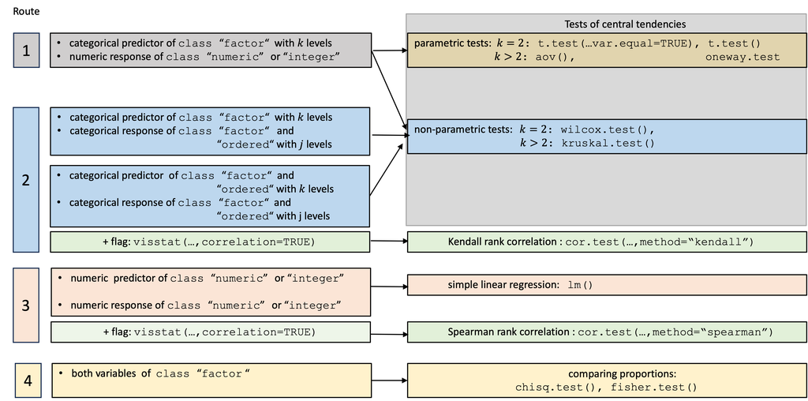

Figure 5.1: Overview of all implemented tests selected based on input class.

Definitions of all implemented test statistics and association measures are referenced in Appendix B. Unless stated otherwise, R function names refer to functions from the `stats` package distributed with R (R Core Team 2026).

## 5.2 General linear model diagnostics

Student’s t-test, Fisher’s ANOVA, and simple linear regression all belong to the general linear model framework (Thompson 2015) and thus share a common set of assumptions: the expected value of the response is a linear function of the predictors, the error terms are mutually independent and normally distributed with expectation 0, and the error variance is constant at $\sigma^2$ (see Appendix A).

### 5.2.1 Visualisation the general linear model assumptions

A core output of `visStatistics` is a diagnostic graphic generated in Route 1 and Route 3 (if `correlation = FALSE`) before the selected test or regression result is shown.

It fits the corresponding linear model and computes raw model residuals.

#### Residual scale used for tests and plots

Formal assumption-test p-values are computed from raw model residuals. For display only, both Route 1 and Route 3 use the same pooled z-scaled residuals to facilitate model comparison. Because these p-values are shown in the same graphic as the diagnostics, the displayed residuals are kept on a constant rescaling of the same residuals:

$$\begin{equation}
z_i = \frac{e_i}{SE_\text{res}},
\; \mathrm{with} \;
SE_\text{res} =
\sqrt{\frac{\sum_i e_i^2}{N-k}} .
\tag{5.1}
\end{equation}$$

Here $N$ is the total sample size, $k$ is the number of fitted model parameters, and $SE_\text{res}$ is the residual standard error. Note that in Route 1 $SE_\text{res}$ equals $\sqrt{MS_\text{within}}$, with $MS_\text{within}$ defined in Equation (B.9).

Route 1 displays the residual histogram, the normal Q–Q plot, and absolute residual spread by group. Route 3 displays the residual histogram, the normal Q–Q plot, z-scaled residuals versus fitted values, and z-scaled residuals versus leverage.

The Route 3 leverage panel therefore differs from the standard `plot.lm()` panel, which uses internally studentised residuals. To retain the influence diagnostic on the common z residual scale, Cook’s distance contours are transformed accordingly (see Appendix B.1).

The first row of the outer title reports p-values of residual-normality checks with the Shapiro–Wilk and Anderson–Darling tests. The second row reports p-values of variance checks: Levene and Bartlett for grouped central-tendency analyses, or Breusch–Pagan for simple regression.

The Route 1 and Route 3 diagnostic-panel designs are illustrated in the worked examples in Figures 6.4, left, and 6.9, left.

The following route-specific sections describe which checks are used for test selection.

## 5.3 Route-specific decision rules

### Route 1: Numeric response, categorical predictor

In the central-tendency branch, the diagnostic panel (see Section 5.2.1) is always generated as first visual output. Figure 5.2 expands the subsequent routing logic.

[figure not shown]

The first split checks group size. When all group-specific sample sizes are greater than 50, the normality of the sampling distribution of the group means can be assumed by the central limit theorem (Lumley et al. 2002; Rasch et al. 2011). The displayed residual-normality p-values then no longer determine routing, to avoid rejecting negligible deviations in large samples (Ghasemi and Zahediasl 2012; Fagerland 2012; Shatz 2024).

Otherwise, the Shapiro–Wilk (SW) p-value computed on raw model residuals determines whether the route remains mean-based.

If normality is rejected ($p_\text{SW} \le \alpha$), non-parametric tests are selected: `wilcox.test()` for two groups, or `kruskal.test()` followed by Holm-adjusted `pairwise.wilcox.test()` for more than two groups.

If normality is not rejected, variance homogeneity is assessed with the package-implemented mean-centred Levene test on raw model residuals ((Levene 1960); see Section B.2.1). This aligns the variance gate with the fitted general linear model. For homoscedastic data, `t.test(var.equal = TRUE)` is applied for two groups, or Fisher’s `aov()` with `TukeyHSD()` for more than two groups. For heteroscedastic data, Welch’s `t.test()` is applied for two groups, or Welch’s `oneway.test()` with the package implementation `games.howell()` ((Games and Howell 1976); see Section B.5.1) for more than two groups.

The box plots are enriched with significance letters to visualise the post-hoc analysis:

ANOVA, Welch ANOVA, and Kruskal–Wallis are omnibus tests: a significant result tells us that *some* group differs, but not which. To identify the differing pairs, `visstat()` tests all pairwise comparisons among the factor levels, defining a family of tests. Because the three omnibus tests rest on different assumptions, each branch uses a matching post-hoc procedure: `TukeyHSD()` after `aov()`, `games.howell()` after `oneway.test()`, and `pairwise.wilcox.test(p.adjust.method = "holm")` after `kruskal.test()`. `TukeyHSD()` controls the family-wise error rate through the studentised range distribution under a common-variance assumption. `games.howell()` uses separate variance estimates and Welch-adjusted degrees of freedom for each pair, making it the post-hoc procedure for the heteroscedastic Welch branch. The Kruskal–Wallis branch uses Holm’s step-down adjustment for the pairwise Wilcoxon tests. Pairs whose adjusted post-hoc $p$-value falls below $\alpha$ are marked with different green significance letters below the box plots; pairs sharing a letter are not significantly different.

### Route 3: Both variables numeric

When both predictor and response are numerical, `visstat()` fits and displays a simple linear regression. The assumption-diagnostic panel described above is displayed, but its checks do not trigger automatic model replacement. The regression plot shows the fitted line $\hat{y} = b_0 + b_1 x$ with pointwise confidence and prediction bands at the specified `conf.level`. The returned object contains the regression statistics, residual-normality tests, pointwise confidence and prediction bands, and the coefficient of determination $R^2$ as effect size (see Appendix C).

However, when `correlation = TRUE` is set explicitly, Spearman’s $\rho$ is computed via `cor.test(..., method = "spearman")`.

Because the choice between modelling a directional relationship and measuring a monotone association cannot be automated from data types alone, Spearman correlation is never triggered automatically. Spearman’s $\rho$ is Pearson’s correlation applied to ranks; see Section B.8.1.

### Route 4: Both variables categorical

When both variables are of class `factor`, `visstat()` tests the variables’ independence using Pearson’s $\chi^2$ test (`chisq.test()`) or Fisher’s exact test (`fisher.test()`), depending on expected cell counts following Cochran’s rule (Cochran 1954): the $\chi^2$ approximation is used if no expected cell count is less than 1 and no more than 20% of cells have expected counts below 5. Yates’ continuity correction is applied by default to $2 \times 2$ tables. The graphical output depends on the selected test. General $R \times C$ Pearson $\chi^2$ tests show a grouped column plot of row percentages with the $p$-value in the title, followed by a mosaic plot from `vcd` (Meyer et al. 2006, 2024) with tiles coloured by Pearson residuals. Yates-corrected $2 \times 2$ $\chi^2$ tests show the grouped column plot only, because the corrected statistic is not decomposed into cell-level residuals. Fisher’s exact test shows absolute counts with count labels above each bar and the $p$-value in the title, so the small cell counts that trigger the exact test remain visible.

# 6 Examples

The examples follow the the routes outlined in Section 5.1 and are chosen such, that all branchings are triggered. Within the group-comparison routes, examples are paired so that the two-group case is followed by its generalisation to more than two groups: Student’s t-test by Fisher’s one-way ANOVA, Welch’s t-test by Welch’s one-way ANOVA, and Wilcoxon rank-sum by Kruskal–Wallis.

## 6.1 Route 1: Numeric response, categorical predictor

### 6.1.1 Student’s t-test and Fisher’s one-way ANOVA

#### 6.1.1.1 Student’s t-test

The `ToothGrowth` dataset records odontoblast length in 60 guinea pigs given vitamin C by orange juice (`OJ`) or ascorbic acid (`VC`). With delivery method as predictor and length as response, the assumption-diagnostic panel shows no residual-normality or variance-homogeneity violation. `visstat()` therefore selects Student’s t-test, and the result panel shows the two-group box plot with the selected test result.

```r
student_ttest <- visstat(ToothGrowth$supp, ToothGrowth$len)
```

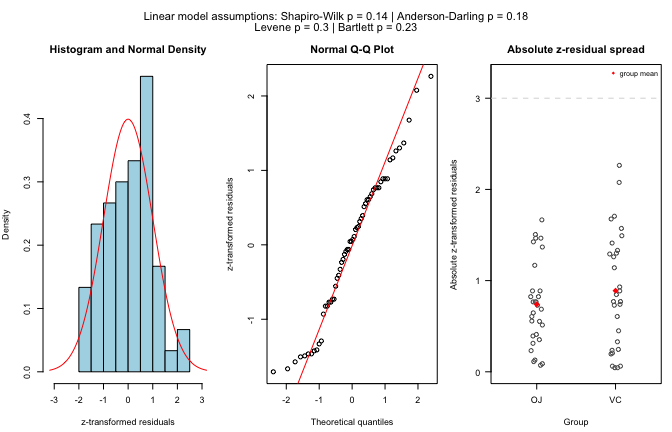

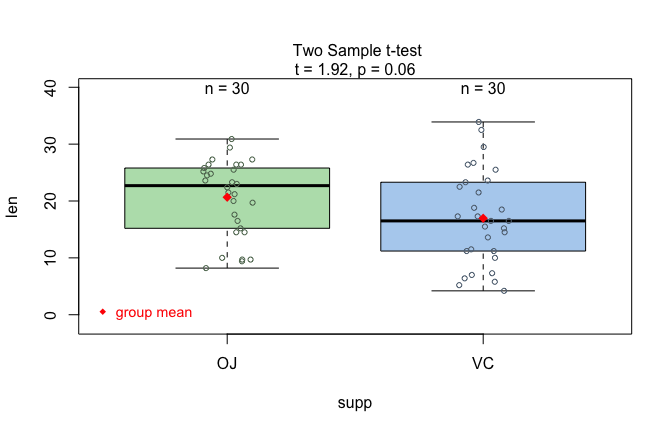

Figure 6.1: Student’s t-test applied to the `ToothGrowth` dataset (`len` vs. `supp`). Assumption diagnostics and box plots of odontoblast length by vitamin C delivery method with the Student t-test result.

#### 6.1.1.2 Fisher’s one-way ANOVA with Tukey HSD post-hoc comparisons

The `PlantGrowth` dataset records yields (as measured by dried weight of plants) for a control group and two treatment groups. With control and treatment groups as predictor and plant weight as response, the assumption-diagnostic panel shows that Shapiro–Wilk does not reject normality of the raw model residuals and `levene.test()` does not reject homoscedasticity. `visstat()` therefore applies Fisher’s one-way ANOVA followed by Tukey HSD post-hoc comparisons. The result panel shows the box plots and post-hoc significance letters. The omnibus F-test is significant at $\alpha = 0.05$, and the Tukey HSD post-hoc comparison finds no significant difference between the control group and either treatment, but the difference between `trt1` and `trt2` is significant.

```r
anova_plantgrowth <- visstat(PlantGrowth$group, PlantGrowth$weight)
```

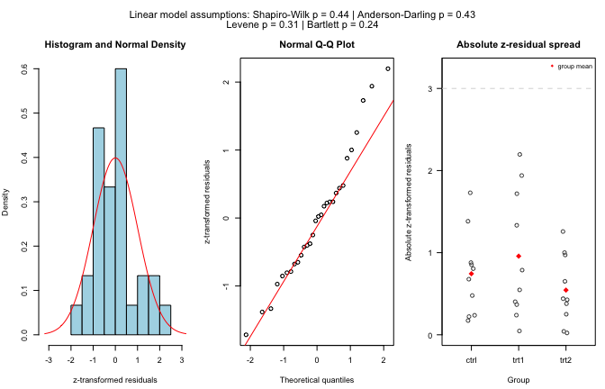

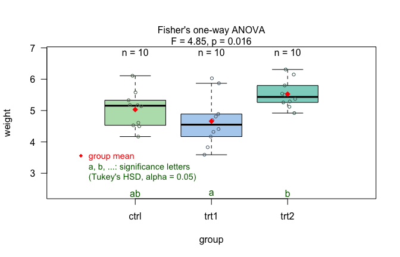

Figure 6.2: Fisher’s one-way ANOVA applied to the `PlantGrowth` dataset (`weight` vs. `group`). Assumption diagnostics and box plots of plant weight by treatment group; Tukey HSD post-hoc comparisons are shown as significance letters ($\alpha = 0.05$).

### 6.1.2 Welch’s t-test and Welch’s one-way ANOVA

#### 6.1.2.1 Welch’s t-test

The *Motor Trend Car Road Tests* dataset (`mtcars`) contains 32 observations, where `mpg` denotes miles per (US) gallon and `am` represents the transmission type (`0` = automatic, `1` = manual). With binary factor `am` and continuous response `mpg`, the assumption-diagnostic panel shows that Shapiro–Wilk does not reject normality of the raw model residuals, while the Levene test detects heteroscedasticity. The routing therefore leads to Welch’s t-test rather than Student’s t-test, and the result panel shows the corresponding two-group comparison.

```r
mtcars$am <- as.factor(mtcars$am)
t_test_stats <- visstat(mtcars$am, mtcars$mpg)
```

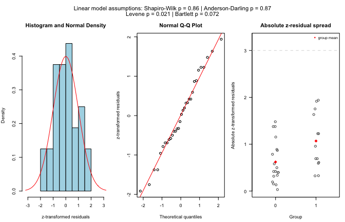

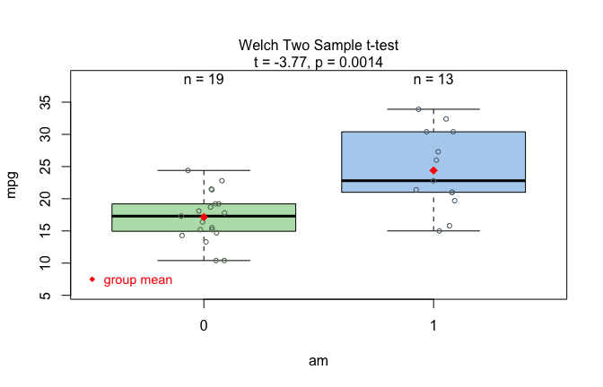

Figure 6.3: Welch’s t-test applied to the `mtcars` dataset (`mpg` vs. `am`). Pooled-residual assumption diagnostics (Shapiro–Wilk, Bartlett, Levene test) and box plots of fuel efficiency by transmission type with the Welch t-test result.

#### 6.1.2.2 Welch’s heteroscedastic one-way ANOVA with Games–Howell post-hoc comparisons

In the `iris` dataset, using `Species` as predictor and `Sepal.Length` as response, the assumption-diagnostic panel shows that Shapiro–Wilk does not reject normality of the raw model residuals, whereas the Levene test rejects homoscedasticity at given $\alpha = 5 \%$. `visstat()` therefore selects Welch’s heteroscedastic one-way ANOVA (`oneway.test()`) and applies Games–Howell post-hoc comparisons. The result panel shows the box plots and Games–Howell significance letters.

```r
welch_anova_iris <- visstat(iris$Species, iris$Sepal.Length)
```

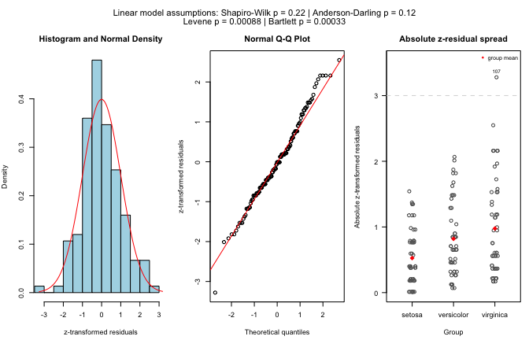

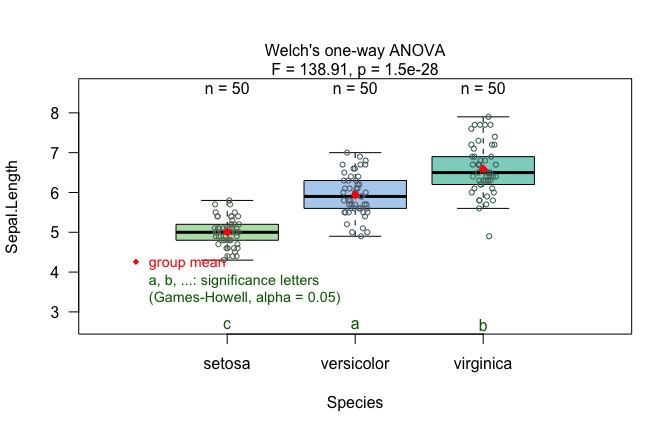

Figure 6.4: Welch’s heteroscedastic one-way ANOVA applied to the `iris` dataset (`Sepal.Length` vs. `Species`). Assumption diagnostics and box plots; Games–Howell post-hoc comparisons are shown as significance letters ($\alpha = 0.05$).

### 6.1.3 Wilcoxon rank-sum test and Kruskal–Wallis test

#### 6.1.3.1 Wilcoxon rank-sum test

The `warpbreaks` dataset records thread breaks during weaving. Using wool type (`A` or `B`) as predictor and the number of breaks as response, the assumption-diagnostic panel shows that the Shapiro–Wilk test rejects normality of the raw model residuals. `visstat()` therefore selects the Wilcoxon rank-sum test, and the result panel shows the rank-based two-group comparison.

```r
wilcoxon_stats <- visstat(warpbreaks$wool, warpbreaks$breaks)
```

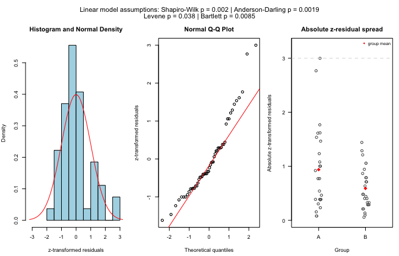

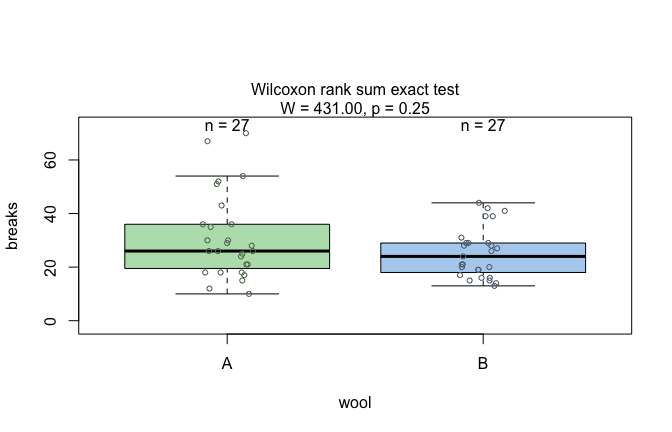

Figure 6.5: Wilcoxon rank-sum test applied to the `warpbreaks` dataset (`breaks` vs. `wool`). Assumption diagnostics (Shapiro–Wilk rejected on raw model residuals; non-parametric path selected) and box plots with the Wilcoxon test result.

#### 6.1.3.2 Kruskal–Wallis rank sum test with pairwise Wilcoxon post-hoc comparisons

In the `iris` data set, `Petal.Width` by `Species` follows a different route than `Sepal.Length` by `Species` above (Figure 6.4), because the assumption diagnostics differ. The assumption-diagnostic panel shows clear departures from normality, and both normality tests return very small $p$-values. Since Shapiro–Wilk falls below $\alpha$, `visstat()` switches to `kruskal.test()` followed by Holm-adjusted `pairwise.wilcox.test()`. The result panel shows the box plots and Holm-adjusted significance letters; all three species differ significantly in petal width, as indicated by distinct letters.

```r
kruskal_iris <- visstat(iris$Species, iris$Petal.Width)
```

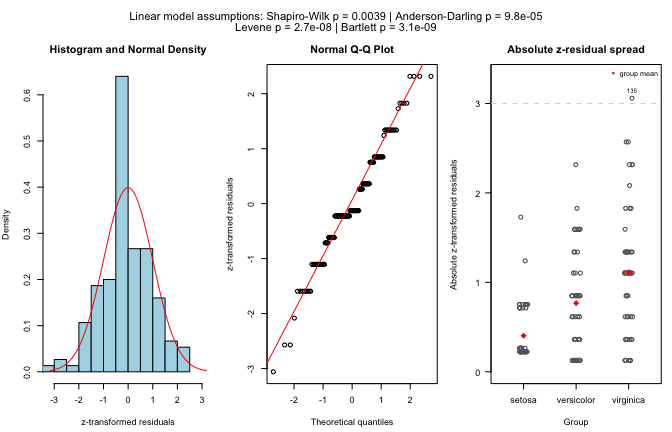

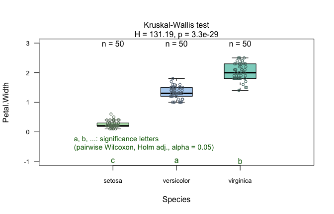

Figure 6.6: Kruskal-Wallis test applied to the `iris` dataset (`Petal.Width` vs. `Species`). Assumption diagnostics (Shapiro–Wilk rejected) and box plots; Holm-adjusted pairwise Wilcoxon post-hoc comparisons are shown as significance letters ($\alpha = 0.05$).

## 6.2 Route 2: Ordered response

The following examples show the two ordered-response cases: an ordered response with a categorical predictor, and two ordered variables with `correlation = TRUE`.

### 6.2.1 Ordered response, categorical factor

#### 6.2.1.1 Wilcoxon rank-sum test with ordered response

The `Titanic` dataset contains passenger counts by, among other variables, passenger class and gender. After expanding the table to individual rows, passenger class is treated as ordered and gender as a two-level predictor. `visstat()` converts the ordered response to integer level codes and selects the Wilcoxon rank-sum test. The result panel therefore displays the rank-test comparison on the numeric level scores (see Figure 6.7, left).

```r
titanic_df <- counts_to_cases(as.data.frame(Titanic))
titanic_df$Class <- ordered(titanic_df$Class,
                            levels = c("1st", "2nd", "3rd", "Crew"))
wilcox_ordered <- visstat(titanic_df$Sex, titanic_df$Class)
```

#### 6.2.1.2 Kruskal–Wallis test with ordered response

When the response is an ordered factor and the predictor has more than two levels, `visstat()` converts the ordered response to integer level codes and routes to `kruskal.test()` followed by Holm-adjusted `pairwise.wilcox.test()`. The result panel shows the Kruskal–Wallis comparison and Holm-adjusted significance letters on the numeric level scores (see Figure 6.7, right). A synthetic survey records perceived car comfort on a five-point scale across three markets.

```r
set.seed(123)
market <- factor(rep(c("Europe", "North America", "Asia"), each = 50))
comfort_numeric <- c(
  sample(1:5, 50, replace = TRUE, prob = c(0.30, 0.30, 0.20, 0.15, 0.05)),
  sample(1:5, 50, replace = TRUE, prob = c(0.10, 0.20, 0.40, 0.20, 0.10)),
  sample(1:5, 50, replace = TRUE, prob = c(0.05, 0.10, 0.20, 0.35, 0.30))
)
survey_data_3 <- data.frame(
  market = market,
  comfort = ordered(comfort_numeric)
)
kruskal_ordered <- visstat(comfort ~ market, data = survey_data_3)
```

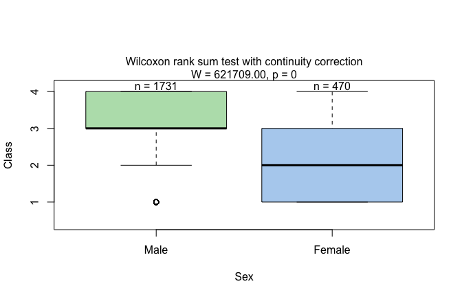

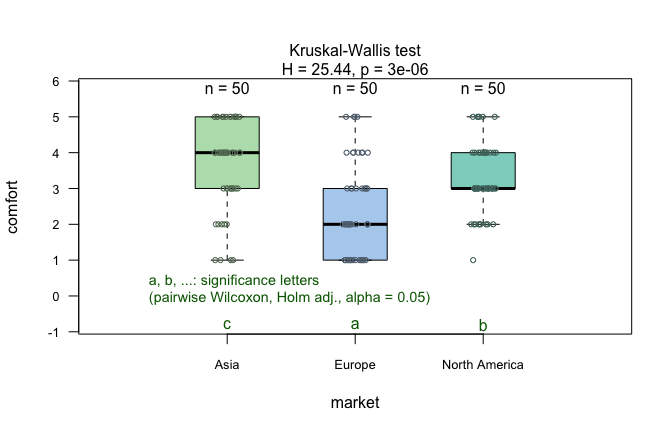

Figure 6.7: Wilcoxon rank-sum test for ordered passenger class by sex in the expanded `Titanic` data (left) and its multi-group generalisation, the Kruskal-Wallis test for ordered car comfort ratings by market (right). Ordered responses are converted to integer level codes; Holm-adjusted pairwise Wilcoxon post-hoc comparisons are shown as significance letters for the Kruskal-Wallis example ($\alpha = 0.05$).

### 6.2.2 Ordered response, ordered factor

The default `correlation = FALSE` path redirects to the Wilcoxon/Kruskal–Wallis route and is not repeated as a separate example. The Kendall output for `correlation = TRUE` is a single jittered rank–rank scatter plot that visualises the monotone trend, colour-codes points by the predictor level, and annotates the plot with $\tau_b$ and the $p$-value.

#### 6.2.2.1 Kendall rank correlation with `correlation = TRUE`

A hypothetical survey of 150 secondary-school students records alcohol consumption frequency and academic performance on five-point ordinal scales. A negative monotone association is induced by construction: students who consume alcohol more frequently tend to have lower academic performance. The Kendall result is shown in Figure 6.8, left.

```r
set.seed(42)
n <- 150
xs <- sample(1:5, n, replace = TRUE)
ys <- pmin(5, pmax(1, (6 - xs) + sample(-1:1, n, replace = TRUE)))
likert_alc  <- c("never", "rarely", "sometimes", "often", "always")
likert_perf <- c("poor",  "fair",   "ok",        "good",  "great")
alcohol     <- ordered(likert_alc[xs],  levels = likert_alc)
performance <- ordered(likert_perf[ys], levels = likert_perf)
kendall_result <- visstat(performance, alcohol, correlation = TRUE)
spearman_air <- visstat(airquality$Wind, airquality$Ozone, correlation = TRUE)
```

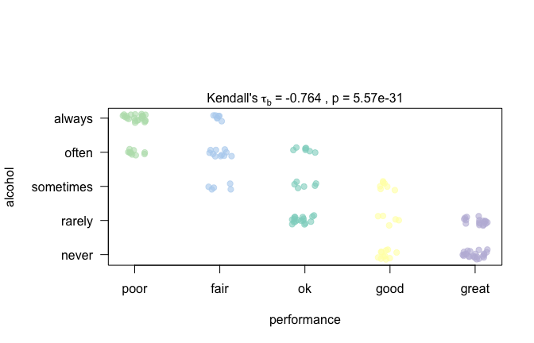

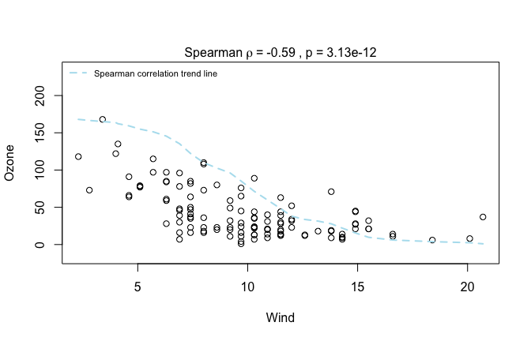

Figure 6.8: Rank-based correlations: Left: Kendall’s $\tau_b$ for a hypothetical survey ($n = 150$): alcohol consumption frequency vs. academic performance (left). Right: Spearman rank correlation of `Wind` and `Ozone` from the `airquality` dataset (`correlation = TRUE`; right). Both plots annotate the corresponding effect measure and $p$-value.

## 6.3 Route 3: Numeric response, numeric predictor

### 6.3.1 Linear regression

The `swiss` dataset records standardised fertility and socioeconomic indicators for 47 French-speaking Swiss provinces in 1888. We examine how the share of draftees achieving the highest army examination score (`Examination`) predicts the fertility measure (`Fertility`), with `conf.level = 0.99`. The diagnostic panel in Figure 6.9, left, shows that both normality tests pass and the Breusch–Pagan test confirms homoscedasticity, supporting the linear model.

```r
linreg_swiss <- visstat(swiss$Examination, swiss$Fertility, conf.level = 0.99)
```

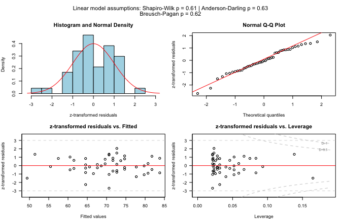

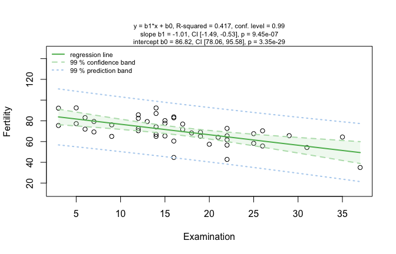

The `airquality` ozone example shows the limits of the automated approach when the default linear model is not an adequate final model. `visstat()` identifies assumption violations and points to analyses outside the automated decision tree. A default `visstat()` call for ozone concentration (`Ozone`) as a function of wind speed (`Wind`) fits the simple linear model.

```r
ozone_lm <- visstat(airquality$Wind, airquality$Ozone)
```

```
## RECOMMENDATION: Consider exploring alternatives outside visstat() such as data transformations,
## generalised linear models, or robust regression. For a non-causal alternative
## consider rerunning with correlation = TRUE.
```

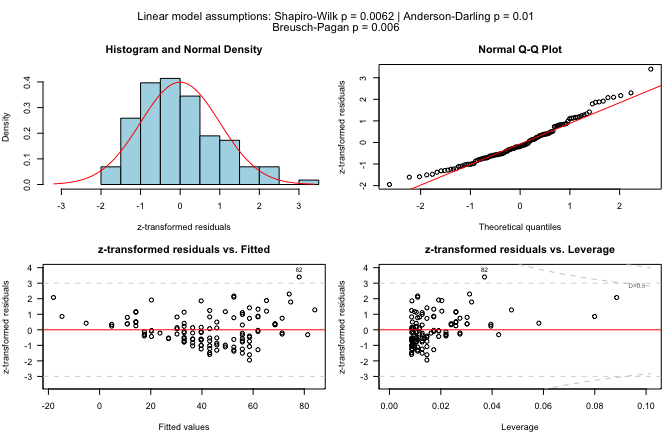

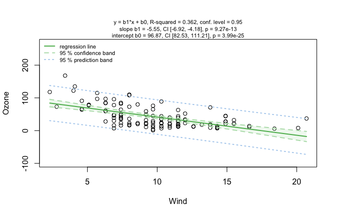

Figure 6.10: Default simple linear regression for `Ozone` by `Wind` in the `airquality` dataset. Assumption diagnostics flag non-normal raw model residuals and heteroscedasticity before alternative routes are considered.

The diagnostic output flags non-normal raw model residuals and heteroscedasticity. The next examples show two distinct choices: an explicit rank-correlation analysis within `visstat()` (`correlation = TRUE`), and a Gamma generalised linear model outside `visstat()`.

### 6.3.2 Spearman rank correlation with `correlation = TRUE`

Correlation analysis requires the explicit flag `correlation = TRUE`. For the ozone example, staying within `visstat()` gives the Spearman analysis shown in Figure 6.8, right.

### 6.3.3 Model exploration outside `visstat()`

As a model outside of `visstat()`, we fit a Gamma generalised linear model with log link. The Gamma family is suited here because Ozone is strictly positive and continuous, and its variance grows with the mean — the structure detected by the Breusch–Pagan test. The log link guarantees positive fitted values.

```r
# Gamma model with log mapping
model_gamma <- glm(Ozone ~ Wind, data = airquality, family = Gamma(link = "log"))
model_gamma$aic
```

```
## [1] 1040.021
```

```r
#Comparison with AIC of simple linear regression
model_lm <- glm(Ozone ~ Wind, data = airquality)
model_lm$aic
```

```
## [1] 1093.187
```

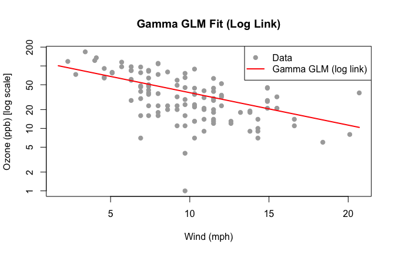

Figure 6.11: Gamma GLM with log link fitted to the `airquality` dataset `Ozone` vs. `Wind`. The red curve shows the fitted Gamma GLM; the y-axis is on a log scale.

For a Gamma generalised linear model with log link, standardised deviance residuals are asymptotically standard normal; we use Shapiro–Wilk and Anderson–Darling as approximate checks of the fitted model:

```r
# Extract standardised deviance residuals
std_dev_res <- rstandard(model_gamma, type = "deviance")
# Validate using the Shapiro-Wilk normality test
shapiro.test(std_dev_res)
```

```
##
##  Shapiro-Wilk normality test
##
## data:  std_dev_res
## W = 0.99245, p-value = 0.7817
```

```r
# Validate using the Anderson-Darling normality test
nortest::ad.test(std_dev_res)
```

```
##
##  Anderson-Darling normality test
##
## data:  std_dev_res
## A = 0.198, p-value = 0.8853
```

## 6.4 Route 4: Two unordered factors

The following examples are based on the `HairEyeColor` contingency table, which is converted to the column-based data frame expected by `visstat()` using `counts_to_cases()`.

### 6.4.1 Pearson’s $\chi^2$ test

With `Eye` and `Hair` from `HairEyeColor`, all expected cell counts exceed the Cochran thresholds (Cochran 1954), so the $\chi^2$ approximation is used. For this $4 \times 4$ table, `visstat()` returns both a grouped bar chart of row percentages and a mosaic plot with tiles coloured by Pearson residuals. The mosaic plot shows which cells drive the association: blue tiles indicate observed counts above expectation and red tiles indicate observed counts below expectation.

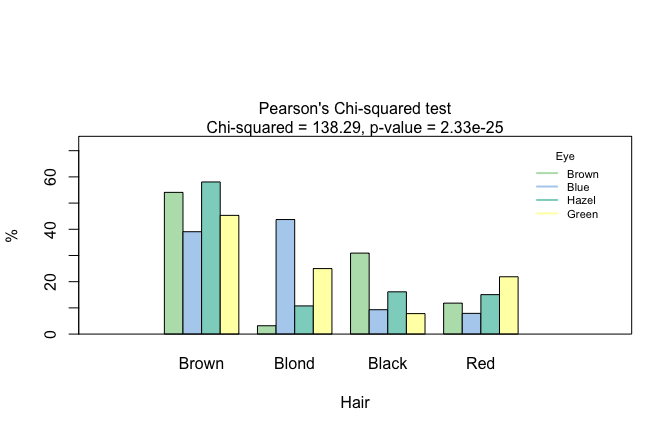

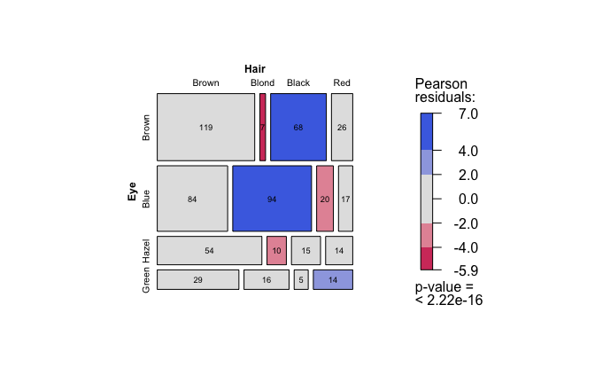

Figure 6.12: Pearson’s $\chi^2$ test applied to the `HairEyeColor` dataset. Grouped bar chart of eye colour by hair colour and mosaic plot with tiles coloured by Pearson residuals (blue: over-represented, red: under-represented).

```r
hair_eye_df <- counts_to_cases(as.data.frame(HairEyeColor))
visstat(hair_eye_df$Eye, hair_eye_df$Hair)
```

### 6.4.2 Pearson’s $\chi^2$ test with Yates’ continuity correction

Restricting `HairEyeColor` to black or brown hair and brown or blue eyes yields a $2 \times 2$ table. Cochran’s rule is still satisfied, so `visstat()` applies Pearson’s $\chi^2$ test with Yates’ continuity correction. The result is shown in Figure 6.13, left.

### 6.4.3 Fisher’s exact test

Restricting `HairEyeColor` to male participants with black or brown hair and hazel or green eyes yields a $2 \times 2$ table where one expected frequency is less than 5, violating Cochran’s rule (Cochran 1954). `visstat()` therefore applies Fisher’s exact test. For $2 \times 2$ tables, the returned object also contains the conditional maximum likelihood estimate of the odds ratio and its confidence interval. The result is shown in Figure 6.13, right.

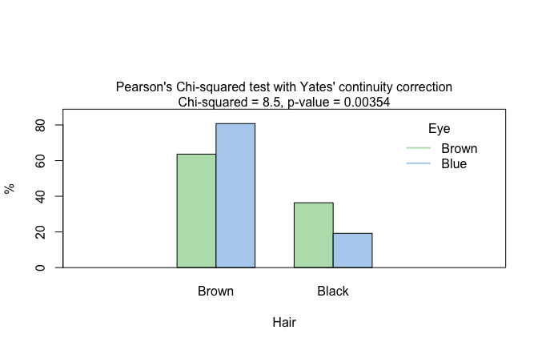

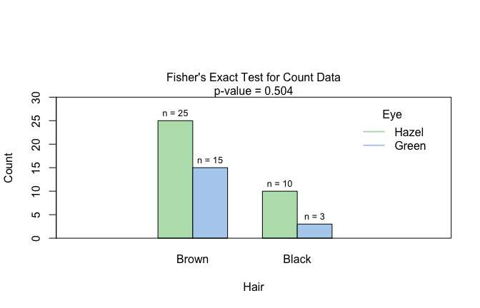

Figure 6.13: Two $2 \times 2$ categorical routes in `HairEyeColor`: Yates-corrected Pearson $\chi^2$ when Cochran’s rule is satisfied (black/brown hair and brown/blue eyes; left), and Fisher’s exact test when expected counts are too small (male participants, black/brown hair, hazel/green eyes; right). The Yates-corrected plot shows row percentages; the Fisher plot shows absolute counts.

```r
hair_black_brown_eyes_brown_blue <- HairEyeColor[1:2, 1:2, ]
hair_black_brown_eyes_brown_blue_df <- counts_to_cases(
  as.data.frame(hair_black_brown_eyes_brown_blue))
yates_stats <- visstat(hair_black_brown_eyes_brown_blue_df$Eye,
                       hair_black_brown_eyes_brown_blue_df$Hair)

hair_eye_male <- HairEyeColor[, , 1]
black_brown_hazel_green <- hair_eye_male[1:2, 3:4]
black_brown_hazel_green_df <- counts_to_cases(
  as.data.frame(black_brown_hazel_green))
fisher_stats <- visstat(black_brown_hazel_green_df$Eye,
                        black_brown_hazel_green_df$Hair)
fisher_stats$estimate   # odds ratio
fisher_stats$conf.int   # 95% CI
```

[output not shown]

# 7 The `visstat` methods

Objects returned by `visstat()` are of class `"visstat"` and support the S3 methods `print()`, `summary()`, and `plot()`.

## 7.1 `print()`

`print()` lists the returned components.

```r
anova_plantgrowth <- visstat(PlantGrowth$group, PlantGrowth$weight)
```

```r
print(anova_plantgrowth)
```

```
## Object of class 'visstat'
##
## Available components:
## [1] "summary statistics of ANOVA" "post-hoc analysis "
## [3] "conf.level"                  "effect_size"
```

## 7.2 `summary()`

`summary()` prints the full returned object, including assumption tests, post-hoc comparisons, confidence level, and `effect_size` where available.

```r
summary(anova_plantgrowth)
```

```
## Summary of visstat object
##
## --- Named components ---
## [1] "summary statistics of ANOVA" "post-hoc analysis "
## [3] "conf.level"                  "effect_size"
##
## --- Contents ---
##
## $summary statistics of ANOVA:
##             Df Sum Sq Mean Sq F value Pr(>F)
## fact         2  3.766  1.8832   4.846 0.0159 *
## Residuals   27 10.492  0.3886
## ---
## Signif. codes:  0 '***' 0.001 '**' 0.01 '*' 0.05 '.' 0.1 ' ' 1
##
## $post-hoc analysis :
##   Tukey multiple comparisons of means
##     95% family-wise confidence level
##
## Fit: aov(formula = samples ~ fact)
##
## $fact
##             diff        lwr       upr     p adj
## trt1-ctrl -0.371 -1.0622161 0.3202161 0.3908711
## trt2-ctrl  0.494 -0.1972161 1.1852161 0.1979960
## trt2-trt1  0.865  0.1737839 1.5562161 0.0120064
##
##
## $conf.level:
## [1] 0.95
##
## $effect_size:
## $name
## [1] "omega-squared"
##
## $estimate
## [1] 0.2040788
##
## $effect_size_method
## [1] "Omega-squared for one-way ANOVA"
```

## 7.3 `plot()`

`plot()` lists available plots by default. With `which`, it either replays a captured plot or reports the selected saved file path.

### 7.3.1 Interactive mode

When `visstat()` is called without a `graphicsoutput` defined (the default interactive mode), the generated plots are captured internally. Calling `plot()` without `which` lists all available plots; calling it with `which` replays the selected plot in the interactive R session.

```r
plot(anova_plantgrowth)
```

```
## Plot [1] captured. Use plot(obj, which = 1) to display.
```

```
## Plot [2] captured. Use plot(obj, which = 2) to display.
```

```r
# Interactive only (not executed during vignette build):
plot(anova_plantgrowth, which = 2)
```

### 7.3.2 Saved graphics

When `visstat()` is called with `graphicsoutput` specified, `plot()` lists the generated file paths instead. All generated graphics can be saved in any file format supported by `Cairo()` (Urbanek and Horner 2025), including “png”, “jpeg”, “pdf”, “svg”, “ps”, and “tiff”. If `plotName` is provided, the main result plot uses this name. The assumption-diagnostic plot adds the prefix `"glm_assumptions_"`. If `plotName` is not provided, file names are generated from the selected plot type and the input variable names.

In the following example, we store the graphics in `png` format in the `plotDirectory` `tempdir()` using the `PlantGrowth` Fisher’s ANOVA example. Here, `plotName` is set explicitly so that the output names are stable.

```r
anova_plantgrowth_stored <- visstat(
  PlantGrowth$group,
  PlantGrowth$weight,
  graphicsoutput = "png",
  plotName = "anova_plantgrowth",
  plotDirectory = tempdir()
)
```

The full file paths of the generated graphics are stored as the attribute `"plot_paths"` on the returned object of class `"visstat"`.

```r
paths <- attr(anova_plantgrowth_stored, "plot_paths")
print(basename(paths))
```

```
## [1] "glm_assumptions_anova_plantgrowth.png"
## [2] "anova_plantgrowth.png"
```

# 8 Discussion

The design of `visStatistics` prioritises transparent, reproducible routing for common two-variable analyses (Strasak et al. 2007; Sato et al. 2017; Chicco et al. 2025) over broad model coverage.

This scope keeps the decision tree inspectable and the graphical output consistent, but it also leaves several modelling choices (e.g. paired tests, interaction terms, multiple linear regression) outside the automated workflow. While one of R’s greatest strengths is the sheer volume of statistical methods available, incorporating a wider array of methods would require additional preliminary assumption checks, which in turn would exacerbate the risk of overall Type I error inflation. Furthermore, expanding the pipeline would result in a highly complex decision tree, rendering the underlying statistical logic increasingly opaque to the user.

`visStatistics` instead focuses on the *vis*ualisation of the chosen test and, where applicable, its post-hoc and assumption tests.

For tests of central tendency, p-values from assumption tests are used as routing criteria, subject to the large sample-size safeguards for normality testing described below. However, no single assumption test maintains optimal Type I error rates and statistical power across all distributions (Olejnik and Algina 1987), and p-values obtained from these tests may be unreliable if their assumptions are violated. In large samples, even minor, random deviations from the null hypothesis can result in statistically significant p-values, leading to type I errors. Conversely, in small samples, substantial violations of the assumption may not reach statistical significance, resulting in type II errors (Kozak and Piepho 2018). Moreover, assumption tests provide no information on the nature of deviations from the expected distribution (Shatz 2024). Thus the assessment of normality or homoscedasticity should never rely solely on p-values but should be complemented by visual inspection of the diagnostic plots generated by `visstat()`.

This limitation extends to combinations of assumption tests. Combining tests for normality and homoscedasticity using simple majority voting inflates the overall Type I error rate. Therefore, automated test selection based solely on p-values cannot replace the visual inspection of sample distributions provided by `visstat()`. Based on the provided diagnostic plots, it may be necessary to override the automated choice of test in individual cases.

`visstat()` also reports an `effect_size` field for each selected test. This estimate should be interpreted alongside the $p$-value, but it does not replace subject-matter judgment about practical relevance (Shatz 2024).

The limitation of p-value-based routing is particularly relevant for normality testing. Normality tests behave poorly at both ends of the sample-size range: with small samples they fail to detect non-normality, and with large samples they flag negligible departures from normality as significant (Ghasemi and Zahediasl 2012; Fagerland 2012; Franc 2025).

This raises the practical question of what should count as a “larger” sample in the decision tree. The answer depends on the shape of the underlying distribution, especially skewness and tail weight (Lumley et al. 2002). Simulation studies suggest that moderately skewed distributions require roughly 40–50 observations for adequate convergence of the sampling distribution of the mean (Fagerland 2012).

Based on this range, when all group-specific sample sizes are greater than 50, residual normality p-values are still reported, but no longer determine automated routing, to avoid inflated type I errors caused by the excessive sensitivity of normality tests in larger samples.

For smaller group-specific sample sizes, a Shapiro–Wilk test is used to route between mean-based and rank-based methods, as simulation studies suggest that it has the highest power among normality tests in small to moderate ($n = 10$ to 100) sample sizes (Razali and Wah 2011).

In the regression branch, violated assumptions are only flagged in the output. When this occurs, the package offers Spearman rank correlation (`correlation = TRUE`) as a non-causal alternative to linear regression. Further alternative methods such as data transformation, generalised linear models or robust regression are not implemented: each requires user judgment – about the transformation family, the link function, or the estimator – that cannot be automated without substantially expanding the decision tree and increasing the risk of Type I error inflation.

Bootstrapping represents another possible alternative to assumption-guided routing. Bootstrapping, as implemented for example in the R package `boot` (Canty and Ripley 2025; Davison and Hinkley 1997), can provide confidence intervals for a wide range of statistics. However, bootstrapping is computationally intensive, often requiring thousands of resamples, and may perform poorly with very small sample sizes. The computational intensity of bootstrap runs counter to the purpose of the `visStatistics` package, which is designed to offer a rapid overview of the data, laying the groundwork for deeper analysis in subsequent steps.

At the graphical level, this design is also kept deliberately low-dependency. The package uses base R graphics and avoids a `ggplot2` (Wickham 2016) dependency, keeping the transitive dependency footprint minimal. For more polished, annotated plots of chosen statistical tests, we refer to packages such as `ggstatsplot` (Patil 2021) or `ggpubr` (Kassambara 2026).

Taken together, these scope decisions define `visStatistics` as a rapid, inspectable first-line workflow for routine two-variable inference rather than a replacement for model-specific statistical analysis.

# 9 Conclusion

`visStatistics` is useful where test selection should be reproducible, visible, and easy to audit. Its value is not that it removes the user’s statistical judgment, but that it exposes the assumptions, routing decisions, effect sizes, and plots that should inform that judgment. The package therefore serves as a transparent entry point for routine two-variable analyses, leaving model-specific extensions to the analyst.

# A The general linear model

In the general linear model a response $Y$ is modelled as a linear combination of $k-1$ predictors $x_j$. The general linear model for observation $i,\;i = 1, \ldots, N$ is then

$$Y_i = \beta_0 + \beta_1 x_{i1} + \cdots + \beta_{k-1} x_{i,k-1} + \varepsilon_i,$$

where $Y_i$ is the response for observation $i$, $x_{ij}$ is the value of predictor $j$ for observation $i$, $\beta_0, \beta_1, \ldots, \beta_{k-1}$ are the $k$ parameters. The model error terms $\varepsilon_i$ are assumed to be independent and normally distributed with expectation 0 and constant variance $\sigma^2$, in short
$$\varepsilon_i \sim \mathcal{N}(0, \sigma^2), \quad\mathrm{mutually\; independent}$$

## A.1 Student’s t-test, Fisher’s ANOVA, and simple linear regression as general linear model

The general linear model provides a unified framework underlying Student’s t-test, Fisher’s ANOVA, and simple linear regression (Thompson 2015);

**Student’s t-test** uses one binary indicator variable $x_{i1}$; testing $H_0: \beta_1 = 0$ is equivalent to testing $H_0: \mu_1 = \mu_2$.

**Fisher’s ANOVA** uses $k-1$ binary indicator variables for $k$ groups; testing $H_0: \beta_1 = \cdots = \beta_{k-1} = 0$ is equivalent to testing equality of all group means.

**Simple linear regression** uses one continuous predictor; $H_0: \beta_1 = 0$ examines whether a linear relationship exists.

# B Test statistics and association measures

In grouped and contingency-table formulae below, $N$ denotes the pooled total sample size and $n_i$ group-specific sample sizes.

## B.1 Normality tests

The package displays both the Shapiro–Wilk test and the Anderson–Darling test to check the normality of raw model residuals $e_i$. The diagnostic panels show the constant-rescaled residuals $z_i$ defined in Equation (5.1). In the Route 3 leverage panel, Cook’s distance is displayed on this same scale as $D_i = z_i^2h_{ii}/\{k(1-h_{ii})^2\}$, where $h_{ii}$ is the $i$th diagonal element of the hat matrix (Cook and Weisberg 1982).

### B.1.1 Shapiro–Wilk test `shapiro.test()`

The Shapiro–Wilk test evaluates whether a sample $x_1,\ldots,x_n$ comes from a normal distribution. Let $x_{(1)}\le \cdots \le x_{(n)}$ be its order statistics. Introduce a reference sample $Y_1,\ldots,Y_n$ of independent standard normal random variables, i.e. $Y_i \sim N(0,1)$ for all $i$, and let $Y_{(1)}\le \cdots \le Y_{(n)}$ be their order statistics used to construct the Shapiro–Wilk weights.

Let $m_i = \operatorname{E}(Y_{(i)})$ and $v_{ij} = \operatorname{Cov}(Y_{(i)}, Y_{(j)})$ for $i,j = 1,\ldots,n$. Define $\mathbf{m} = (m_1,\ldots,m_n)^\top$ and $V = (v_{ij})_{i,j=1}^n$.

The vector $\mathbf{m}$ contains the expected standard-normal order statistics, and $V$ is their covariance matrix. Let $\mathbf{a}=(a_1,\ldots,a_n)^\top$ be the resulting vector of normalised weights for the ordered observed sample values

$$\mathbf{a}
=\frac{V^{-1}\mathbf{m}}
{\sqrt{\left(\mathbf{m}^\top V^{-1}V^{-1}\mathbf{m}\right)}}.$$
Then the Shapiro–Wilk statistic (Shapiro and Wilk 1965) is

$$\begin{equation}
W=\frac{\left(\sum_{i=1}^{n} a_i x_{(i)}\right)^2}
{\sum_{i=1}^{n} (x_i-\bar{x})^2}
\tag{B.1}
\end{equation}$$

$W$ takes values in $(0, 1]$; values close to 1 indicate normality.

### B.1.2 Anderson–Darling test `ad.test()`

The Anderson–Darling test (Anderson and Darling 1952) is particularly sensitive to deviations in the tails of the distribution (Razali and Wah 2011; Yap and Sim 2011). Let $z_i = (x_{(i)} - \bar{x})/s,\; i=1,2,\ldots,n$ be the standardised order statistics of $x_i$, where $s$ is the sample standard deviation, and let $\Phi$ denote the standard normal cumulative distribution function. The test statistic is

$$\begin{equation}
A^2 = -n - \frac{1}{n}\sum_{i=1}^{n}(2i-1)
\left[\ln\Phi(z_i) + \ln\!\left(1 - \Phi(z_{n+1-i})\right)\right]
\tag{B.2}
\end{equation}$$

The implementation uses `ad.test()` from `nortest` (Gross and Ligges 2015).

## B.2 Homoscedasticity tests

### B.2.1 The mean-centred Levene test `levene.test()`

The package implementation uses Levene’s original mean-centred proposal (Levene 1960). The package’s own function `levene.test()` is the sole driver of the parametric/Welch branching decision.

For each observation $y_{ij}$ in group $i$, the absolute deviation from the group mean $\bar{y}_i$ is

$$z_{ij} = |y_{ij} - \bar{y}_i|.$$

In Route 1 the same calculation is applied to raw model residuals; the group means of these residuals are zero by construction.

The test statistic is the $F$-statistic from a one-way ANOVA on the $z_{ij}$ values:

$$\begin{equation}
F = \frac{(N-k)\displaystyle\sum_{i=1}^{k} n_i (\bar{z}_i - \bar{z})^2}
{(k-1)\displaystyle\sum_{i=1}^{k}\sum_{j=1}^{n_i}(z_{ij} - \bar{z}_i)^2},
\tag{B.3}
\end{equation}$$

where $k$ is the number of groups, $N = \sum_{i=1}^k n_i$ is the total sample size, $n_i$ is the sample size of group $i$, $\bar{z}_i$ is the mean of the absolute deviations within group $i$, and $\bar{z}$ is the overall mean of all absolute deviations. Under the null hypothesis of equal variances the statistic follows $F(k-1, N-k)$.

### B.2.2 Bartlett’s test `bartlett.test()`

Bartlett’s test (Bartlett 1937) has greater power than Levene’s test when normality holds (Allingham and Rayner 2012). Its test statistic is

$$\begin{equation}
K^2 = \frac{(N-k)\ln s_p^2 - \displaystyle\sum_{i=1}^k (n_i-1)\ln s_i^2}
{1 + \dfrac{1}{3(k-1)}\!\left(\displaystyle\sum_{i=1}^k \frac{1}{n_i-1} - \frac{1}{N-k}\right)},
\tag{B.4}
\end{equation}$$

where $k$ is the number of groups, $N = \sum_{i=1}^k n_i$ is the total sample size, $n_i$ is the sample size of group $i$, $s_i^2$ is the sample variance of group $i$, and $s_p^2$ is the pooled variance

$$s_p^2 = \frac{1}{N-k}\sum_{i=1}^k (n_i-1)\,s_i^2.$$

Under the null hypothesis the statistic approximately follows $\chi^2(k-1)$.

### B.2.3 Breusch–Pagan test `bp.test()`

For simple linear regression, group-based variance tests are not applicable. The package implementation `bp.test()` performs the Breusch–Pagan test (Breusch and Pagan 1979), which assesses whether the variance of the residuals from the regression model depends on the predictor values. Let $e_i$ be the residuals from the fitted regression model. The auxiliary regression models $e_i^2$ as a function of the predictors. Let $R^2_\text{aux}$ denote the coefficient of determination from this auxiliary regression. Crucially, while a high $R^2$ is typically a sign of a strong model, here it indicates a failure of the constant-variance assumption: a higher $R^2_\text{aux}$ means the error variance follows a systematic, non-random pattern. The Breusch–Pagan statistic is then calculated as:

$$\begin{equation}
BP = n R^2_\text{aux}
\tag{B.5}
\end{equation}$$

which is compared asymptotically to a $\chi^2$ distribution with degrees of freedom equal to the number of predictors in the auxiliary regression.

## B.3 Student’s t-test and Welch’s t-test

The test statistic for Student’s t-test (`t.test(..., var.equal = TRUE)`) is

$$\begin{equation}
t = \frac{\bar{x}_1 - \bar{x}_2}{s_p \sqrt{\dfrac{1}{n_1} + \dfrac{1}{n_2}}},
\tag{B.6}
\end{equation}$$

where $\bar{x}_1$ and $\bar{x}_2$ are the sample means, $n_1$ and $n_2$ the sample sizes, and $s_p$ the pooled standard deviation

$$s_p = \sqrt{\frac{(n_1-1)s_1^2 + (n_2-1)s_2^2}{n_1+n_2-2}},$$

with $s_1^2$ and $s_2^2$ the sample variances. The statistic follows a $t$-distribution with $\nu = n_1 + n_2 - 2$ degrees of freedom.

Welch’s t-test (`t.test(..., var.equal = FALSE)`) relaxes the homoscedasticity assumption. Its statistic is

$$\begin{equation}
t = \frac{\bar{x}_1 - \bar{x}_2}{\sqrt{s_1^2/n_1 + s_2^2/n_2}}
\tag{B.7}
\end{equation}$$

with degrees of freedom approximated by the Welch–Satterthwaite equation:

$$\nu \approx \frac{\left(\dfrac{s_1^2}{n_1} + \dfrac{s_2^2}{n_2}\right)^2}
{\dfrac{(s_1^2/n_1)^2}{n_1-1} + \dfrac{(s_2^2/n_2)^2}{n_2-1}}.$$

Welch’s methods outperform their classical counterparts when variances differ (Moser and Stevens 1992; Fagerland and Sandvik 2009; Delacre et al. 2017).

## B.4 Wilcoxon rank-sum test

The two-level factor `x` defines two groups with sample sizes $n_1$ and $n_2$. All $N = n_1 + n_2$ observations are pooled and assigned ranks $1$ to $N$. Let $W_1 = \sum_{i=1}^{n_1} R(x_{1,i})$ denote the rank sum of the first group, where $R(x_{1,i})$ is the rank of observation $x_{1,i}$ in the pooled sample. The test statistic returned by `wilcox.test()` is the Mann–Whitney $U$ statistic (Mann and Whitney 1947) of the first group:

$$\begin{equation}
W = U_1 = W_1 - \frac{n_1(n_1+1)}{2}
\tag{B.8}
\end{equation}$$

An exact $p$-value is computed when both groups contain fewer than 50 observations and the data contain no ties; otherwise a normal approximation with continuity correction is used.

## B.5 Fisher’s one-way ANOVA and Welch’s heteroscedastic ANOVA

Fisher’s ANOVA test statistic is

$$\begin{equation}
\begin{aligned}
F &= \frac{MS_\text{between}}{MS_\text{within}}
= \frac{SS_\text{between}/(k-1)}{SS_\text{within}/(N-k)}
= \frac{\displaystyle\sum_{i=1}^{k} n_i (\bar{x}_i - \bar{x})^2\;/\;(k-1)}
{\displaystyle\sum_{i=1}^{k}\sum_{j=1}^{n_i}(x_{ij}-\bar{x}_i)^2\;/\;(N-k)},
\end{aligned}
\tag{B.9}
\end{equation}$$

where $MS_\text{between}$ and $MS_\text{within}$ are the between-group and within-group mean squares, $SS_\text{between}$ and $SS_\text{within}$ are the corresponding sums of squares, $k$ is the number of groups, $N = \sum_{i=1}^k n_i$ is the total sample size, $\bar{x}_i$ is the mean of group $i$, $\bar{x}$ is the overall mean, and $x_{ij}$ is observation $j$ in group $i$.

From Equation (B.9) follows that in the two-sample case ($k=2$), the squared test statistic of Student’s t-test equals the Fisher ANOVA test statistic, $t^2 = F$, resulting in identical $p$-values for `t.test(var.equal = TRUE)` and `aov()`.

Under the null hypothesis $F \sim F(k-1, N-k)$, post-hoc comparisons use Tukey’s Honest Significant Differences `TukeyHSD()`, which controls the family-wise error rate.

Welch’s heteroscedastic ANOVA (`oneway.test()`) down-weights groups with large variance. Its test statistic is

$$\begin{equation}
F_W = \frac{\displaystyle\sum_{i=1}^{k} w_i (\bar{y}_i - \bar{y}_w)^2\;/\;(k-1)}
{1 + \dfrac{2(k-2)}{k^2-1} \displaystyle\sum_{i=1}^{k} \dfrac{(1-w_i/w)^2}{n_i-1}},
\tag{B.10}
\end{equation}$$

where $w_i = n_i/s_i^2$ are the inverse-variance weights, $w = \sum_{i=1}^{k} w_i$, and $\bar{y}_w = \sum_{i=1}^{k} w_i \bar{y}_i / w$ is the weighted grand mean. Degrees of freedom are adjusted via a Satterthwaite-type approximation.

### B.5.1 Post-hoc comparison `games.howell()`

Post-hoc comparisons use the package implementation `games.howell()` (Games and Howell 1976). For each pairwise comparison, the two groups are denoted as 1 and 2. The function computes

$$d = \bar{y}_1 - \bar{y}_2,$$

with standard error

$$SE = \sqrt{\frac{s_1^2}{n_1} + \frac{s_2^2}{n_2}}$$

and test statistic

$$t = \frac{d}{SE}.$$

The degrees of freedom use the Welch–Satterthwaite equation given above. Two-sided $p$-values are computed from the corresponding $t$ distribution and then adjusted with Holm’s method (Holm 1979). Confidence intervals are computed as $d \pm t_{1-\alpha/2,\nu}SE$ and are not adjusted for multiple comparisons. Significant letter displays are produced by `multcompLetters()` from `multcompView` (Graves et al. 2026).

## B.6 Kruskal–Wallis test

When normality is rejected, `kruskal.test()` tests whether the groups come from the same population based on ranks:

$$\begin{equation}
H = \frac{12}{N(N+1)} \sum_{i=1}^{k} n_i \left(\bar{R}_i - \bar{R}\right)^2,
\tag{B.11}
\end{equation}$$

where $n_i$ is the sample size of group $i$, $k$ is the number of groups, $\bar{R}_i$ is the average rank of group $i$, $N$ is the total sample size, and $\bar{R} = (N+1)/2$ is the expected average rank under the null hypothesis. The statistic approximately follows $\chi^2(k-1)$. Post-hoc comparisons use Holm-adjusted `pairwise.wilcox.test()` (Holm 1979).

## B.7 Pearson’s $\chi^2$ test and Fisher’s exact test

Let $O_{ij}$ and $E_{ij}$ denote the observed and expected frequencies in row $i$ and column $j$ of an $R \times C$ contingency table, where rows index the $R$ levels of the response $y$ and columns the $C$ levels of the predictor $x$. The Pearson residual for cell $(i,j)$ is

$$r_{ij} = \frac{O_{ij} - E_{ij}}{\sqrt{E_{ij}}}, \quad i = 1,\ldots,R,\quad j = 1,\ldots,C.$$

The test statistic of Pearson’s $\chi^2$ test is

$$\begin{equation}
\chi^2 = \sum_{i=1}^{R}\sum_{j=1}^{C} r_{ij}^2
= \sum_{i=1}^{R}\sum_{j=1}^{C} \frac{(O_{ij}-E_{ij})^2}{E_{ij}}
\tag{B.12}
\end{equation}$$

compared to $\chi^2\!\left((R-1)(C-1)\right)$. For $2\times 2$ tables, Yates’ continuity correction is applied by default. For general $R \times C$ tables, `visstat()` supplements the bar chart with a mosaic plot in which tiles are coloured by $r_{ij}$ (blue: positive, red: negative).

Fisher’s exact test (`fisher.test()`) is applied when Cochran’s rule (Cochran 1954) is violated. The test calculates an exact $p$-value by conditioning on the observed margins of an $R \times C$ contingency table. Let $T = (n_{ij})$ denote the observed table. To maintain consistency with the `y ~ x` (response ~ predictor) framework used throughout `visStatistics`, rows ($i=1,\ldots,R$) represent the levels of the response variable $y$ and columns ($j=1,\ldots,C$) represent the levels of the predictor $x$. The row totals are $n_{i\cdot} = \sum_{j=1}^C n_{ij}$ and the column totals are $n_{\cdot j} = \sum_{i=1}^R n_{ij}$.

In the $2 \times 2$ case ($R=2, C=2$), the table is structured as follows:

$$\begin{array}{c|cc|c}
& x_1 & x_2 & \text{Row sums} \\
\hline
y_1 & n_{11} & n_{12} & n_{1\cdot} \\
y_2 & n_{21} & n_{22} & n_{2\cdot} \\
\hline
\text{Column sums} & n_{\cdot 1} & n_{\cdot 2} & N
\end{array}$$

The exact probability of observing this table under the null hypothesis of independence, given the fixed margins, is given by the hypergeometric probability mass function:

$$\begin{equation}
\mathbb{P}(T \mid n_{1\cdot}, n_{2\cdot}, n_{\cdot 1}, n_{\cdot 2})
= \frac{\binom{n_{1\cdot}}{n_{11}} \binom{n_{2\cdot}}{n_{21}}}{\binom{N}{n_{\cdot 1}}},
\tag{B.13}
\end{equation}$$

where $N = n_{1\cdot} + n_{2\cdot} = n_{\cdot 1} + n_{\cdot 2}$ is the total sample size. The $p$-value is computed by summing the probabilities of all tables with the same margins whose probabilities under the null are less than or equal to that of the observed table. For general $R \times C$ tables, `fisher.test()` generalises this approach using the multivariate hypergeometric distribution. For $2 \times 2$ tables, `fisher.test()` additionally returns the conditional maximum likelihood estimate of the odds ratio

$$\begin{equation}
\widehat{\text{OR}} = n_{11}n_{22}/(n_{12}n_{21})
\tag{B.14}
\end{equation}$$

and its confidence interval.

## B.8 Rank Association Measures

### B.8.1 Spearman rank correlation

For two numeric variables with `correlation = TRUE`, `visstat()` calls `cor.test(x, y, method = "spearman")` to measure the monotonic association between $x$ and $y$ using ranks. Spearman’s $\rho$ is Pearson’s $r$ applied to the ranks:

$$\begin{equation}
\rho = r(\operatorname{rank}(x), \operatorname{rank}(y)),
\tag{B.15}
\end{equation}$$

where $r(u, v)$ denotes Pearson’s correlation coefficient:

$$r(u,v)
=
\frac{\sum_{i=1}^{n}(u_i-\bar u)(v_i-\bar v)}
{\sqrt{\sum_{i=1}^{n}(u_i-\bar u)^2}\,
\sqrt{\sum_{i=1}^{n}(v_i-\bar v)^2}}.$$

Here $u_i = \operatorname{rank}(x_i)$ and $v_i = \operatorname{rank}(y_i)$ are the ranks of the $n$ paired observations, and $\bar{u}$ and $\bar{v}$ are their sample means.

For inference, `cor.test(..., method = "spearman")` computes an exact $p$-value for small samples without ties by evaluating all $n!$ rank permutations. For larger samples or when ties are present, it uses an approximation to the null distribution of the rank association measure or its asymptotic transformation. No distributional assumptions on the original data are required.

A separate Pearson-correlation branch is not implemented. In simple linear regression with an intercept, the two-sided test of zero slope and the two-sided test of zero Pearson correlation return the same $p$-value. Pearson correlation would therefore not add a separate inferential route to the default regression branch.

### B.8.2 Kendall’s $\tau_b$

For two ordinal variables with $n$ joint observations, let $C$ denote the number of concordant pairs (those whose ranks agree in both variables) and $D$ the number of discordant pairs. Kendall’s $\tau_b$ is defined as

$$\begin{equation}
\tau_b \;=\; \frac{C - D}
{\sqrt{\left(n_0 - n_1\right)\left(n_0 - n_2\right)}},
\tag{B.16}
\end{equation}$$

where $n_0 = n(n-1)/2$ is the total number of observation pairs, $n_1 = \sum_i t_i(t_i-1)/2$ is the number of pairs tied in the response, and $n_2 = \sum_j u_j(u_j-1)/2$ is the number of pairs tied in the predictor. The denominator correction makes $\tau_b$ attain $\pm 1$ even with ties, which Spearman’s $\rho$ does not (Kendall 1945). With few ordered levels (e.g., five-point Likert items), ties are unavoidable; this is the principal reason to prefer $\tau_b$ over Spearman’s $\rho$ in this setting (Agresti 2010).

`visstat()` calls `cor.test(as.numeric(y), as.numeric(x), method = "kendall", exact = FALSE)` and reports $\tau_b$, the asymptotic test statistic $z = \tau_b / \operatorname{SE}(\tau_b)$, and the two-sided $p$-value.

# C Effect size

Statistical significance is strongly affected by sample size, while effect-size estimates are intended to support comparisons across studies regardless of sample size (Levine and Hullett 2002).

To avoid additional package dependencies, `effect_size()` extracts, where possible, the effect sizes from base R `stats` output where available and implements the remaining formulae internally (Hedges 1981; Kerby 2014; Olejnik and Algina 2003; Ben-Shachar et al. 2020; Kelley 1935; Bergsma 2013).

| Analysis | R call | Effect size | Formula | Source |
| --- | --- | --- | --- | --- |
| Student’s $t$-test | `t.test(..., var.equal = TRUE)` | Hedges’ $g_{s_p}$ (pooled) | $g_{s_p} = J\cdot(\bar{x}_1-\bar{x}_2)/s_p$ | (Hedges 1981) |
| Welch’s $t$-test | `t.test(..., var.equal = FALSE)` | Hedges’ $g_{s^{*}}$ (non-pooled) | $g_{s^{*}} = J\cdot(\bar{x}_1-\bar{x}_2)/s^{*}$ | (Hedges 1981) |
| Wilcoxon rank-sum | `wilcox.test()` | rank-biserial $r$ | $r = 2\cdot W/(n_1\cdot n_2) - 1$ | (Kerby 2014) |
| Fisher’s ANOVA | `aov()` | $\omega^2$ | $\nu_1\cdot(F-1)/(\nu_1\cdot F + \nu_2 + 1)$ | (Olejnik and Algina 2003) |
| Welch’s ANOVA | `oneway.test()` | $\omega^2$ (approx.) | $\nu_1\cdot(F_W-1)/(\nu_1\cdot F_W + \nu_2 + 1)$ | (Ben-Shachar et al. 2020) |
| Kruskal–Wallis | `kruskal.test()` | Kelley-adjusted $\eta_H^2$ | $(H - k + 1)/(N - k)$ | (Kelley 1935) |
| Linear regression | `lm()` | $R^2$ | $R^2 = 1 - SS_\text{res}/SS_\text{tot}$ | `summary(lm())$r.squared` |
| Spearman | `cor.test(method = "spearman")` | $\rho$ | $\rho = r(\operatorname{rank}(x),\operatorname{rank}(y))$, Eq. (B.15) | `cor.test()$estimate` |
| Kendall | `cor.test(method = "kendall")` | $\tau_b$ | $\tau_b = (C-D)/\sqrt{(n_0-n_1)(n_0-n_2)}$, Eq. (B.16) | `cor.test()$estimate` |
| Pearson $\chi^2$ ($R\times C$) | `chisq.test()` | Cramér’s $V$ | $V_{R\times C} = \sqrt{\chi^2/(N\cdot(\min(R,C)-1))}$ | (Bergsma 2013) |
| Pearson $\chi^2$ ($2\times 2$) | `chisq.test()` | $\phi$ | $V_{2\times 2} = \sqrt{\chi^2/N}$ | (Bergsma 2013) |
| Fisher’s exact ($2\times 2$) | `fisher.test()` | odds ratio | $\widehat{\text{OR}} = n_{11}n_{22}/(n_{12}n_{21})$, Eq. (B.14) | `fisher.test()$estimate` |

Here:

- $J$: Hedges’ small-sample correction factor, $J = \Gamma((N-2)/2)\,/\,(\sqrt{(N-2)/2}\;\Gamma((N-3)/2))$.
- $s^{*}$: non-pooled average-variance standardizer, $s^{*} = \sqrt{(s_1^2+s_2^2)/2}$.
- $\nu_1$, $\nu_2$: numerator and denominator degrees of freedom; for Fisher’s ANOVA, $\nu_1=k-1$ and $\nu_2=N-k$; for Welch’s ANOVA, $\nu_1$ and $\nu_2$ are returned by `oneway.test()`.
- $SS_\text{res}=\sum_i(Y_i-\hat{Y}_i)^2$ is the residual sum of squares, where $\hat{Y}_i$ is the predicted value, and
- $SS_\text{tot}=\sum_i(Y_i-\bar{Y})^2$ is the total sum of squares.

All other variables used in the formulae above are defined in the corresponding “Analysis” section.

# References

Agresti, Alan. 2010. *Analysis of Ordinal Categorical Data*. 1st ed. Wiley Series in Probability and Statistics. Wiley. https://doi.org/10.1002/9780470594001.

Akaike, Hirotugu. 1974. “A New Look at the Statistical Model Identification.” *IEEE Transactions on Automatic Control* 19 (6): 716–23. https://doi.org/10.1109/TAC.1974.1100705.

Allingham, David, and J. C. W. Rayner. 2012. “Testing Equality of Variances for Multiple Univariate Normal Populations.” *Journal of Statistical Theory and Practice* 6 (3): 524–35. https://doi.org/10.1080/15598608.2012.695703.

Anderson, T. W., and D. A. Darling. 1952. “Asymptotic Theory of Certain "Goodness of Fit" Criteria Based on Stochastic Processes.” *The Annals of Mathematical Statistics* 23 (2): 193–212. https://doi.org/10.1214/aoms/1177729437.

Bartlett, M. S. 1937. “Properties of Sufficiency and Statistical Tests.” *Proceedings of the Royal Society of London. Series A, Mathematical and Physical Sciences* 160 (901): 268–82. https://doi.org/10.1098/rspa.1937.0109.

Ben-Shachar, Mattan S., Daniel Lüdecke, and Dominique Makowski. 2020. “Effectsize: Estimation of Effect Size Indices and Standardized Parameters.” *Journal of Open Source Software* 5 (56): 2815. https://doi.org/10.21105/joss.02815.

Bergsma, Wicher. 2013. “A Bias-Correction for Cramer’s V and Tschuprow’s T.” *Journal of the Korean Statistical Society* 42 (3): 323–28. https://doi.org/10.1016/j.jkss.2012.10.002.

Bijlenga, Philippe, Renato Gondar, Sabine Schilling, et al. 2017. “PHASES Score for the Management of Intracranial Aneurysm: A Cross-Sectional Population-Based Retrospective Study.” *Stroke* 48 (8): 2105–12. https://doi.org/10.1161/STROKEAHA.117.017391.

Breusch, T. S., and A. R. Pagan. 1979. “A Simple Test for Heteroscedasticity and Random Coefficient Variation.” *Econometrica* 47 (5): 1287–94. https://doi.org/10.2307/1911963.

Brodeur, Abel, Nikolai Cook, and Anthony Heyes. 2020. “Methods Matter: P-Hacking and Publication Bias in Causal Analysis in Economics.” *American Economic Review* 110 (11): 3634–60. https://doi.org/10.1257/aer.20190687.

Canty, Angelo, and Brian Ripley. 2025. *Boot: Bootstrap Functions*. Manual. https://doi.org/10.32614/CRAN.package.boot.

Chicco, Davide, Andrea Sichenze, and Giuseppe Jurman. 2025. “A Simple Guide to the Use of Student’s t-Test, Mann-Whitney U Test, Chi-squared Test, and Kruskal-Wallis Test in Biostatistics.” *BioData Mining* 18 (1): 56. https://doi.org/10.1186/s13040-025-00465-6.

Cochran, William G. 1954. “The Combination of Estimates from Different Experiments.” *Biometrics* 10 (1): 101. https://doi.org/10.2307/3001666.

Cook, R. Dennis, and Sanford Weisberg. 1982. *Residuals and Influence in Regression*. New York: Chapman and Hall.

Davison, Anthony Christopher, and David Victor Hinkley. 1997. *Bootstrap Methods and Their Applications*. Cambridge University Press. https://doi.org/10.1017/CBO9780511802843.

Delacre, Marie, Daniël Lakens, and Christophe Leys. 2017. “Why Psychologists Should by Default Use Welch’s t-Test Instead of Student’s t-Test.” *International Review of Social Psychology* 30 (1): 92–101. https://doi.org/10.5334/irsp.82.

Fagerland, Morten W. 2012. “T-Tests, Non-Parametric Tests, and Large Studies—a Paradox of Statistical Practice?” *BMC Medical Research Methodology* 12 (1): 78. https://doi.org/10.1186/1471-2288-12-78.

Fagerland, Morten W., and Leiv Sandvik. 2009. “Performance of Five Two-Sample Location Tests for Skewed Distributions with Unequal Variances.” *Contemporary Clinical Trials* 30 (5): 490–96. https://doi.org/10.1016/j.cct.2009.06.007.

Franc, Jeffrey Michael. 2025. “The Misuse of Normality Tests as Gatekeepers for Research in Prehospital and Disaster Medicine.” *Prehospital and Disaster Medicine* 40 (5): 241–42. https://doi.org/10.1017/S1049023X25101465.

Games, Paul A., and John F. Howell. 1976. “Pairwise Multiple Comparison Procedures with Unequal N’s and/or Variances: A Monte Carlo Study.” *Journal of Educational Statistics* (US) 1 (2): 113–25. https://doi.org/10.2307/1164979.

Garcia, Luiz. 2026. *autotestR: Automated Functions for Basic Statistical Tests*. Manual. https://doi.org/10.32614/CRAN.package.autotestR.

Ghasemi, Asghar, and Saleh Zahediasl. 2012. “Normality Tests for Statistical Analysis: A Guide for Non-Statisticians.” *International Journal of Endocrinology and Metabolism* 10 (2): 486–89. https://doi.org/10.5812/ijem.3505.

Graves, Spencer, Hans-Peter Piepho, and Luciano Selzer. 2026. *multcompView: Visualizations of Paired Comparisons*. Manual. https://doi.org/10.32614/CRAN.package.multcompView.

Gross, Juergen, and Uwe Ligges. 2015. *Nortest: Tests for Normality*. Manual. https://doi.org/10.32614/CRAN.package.nortest.

Hayat, Matthew J., Amanda Powell, Tessa Johnson, and Betsy L. Cadwell. 2017. “Statistical Methods Used in the Public Health Literature and Implications for Training of Public Health Professionals.” *PLOS ONE* 12 (6): e0179032. https://doi.org/10.1371/journal.pone.0179032.

Hedges, Larry V. 1981. “Distribution Theory for Glass’s Estimator of Effect Size and Related Estimators.” *Journal of Educational Statistics* 6 (2): 107–28. https://doi.org/10.3102/10769986006002107.

Holm, Sture. 1979. “A Simple Sequentially Rejective Multiple Test Procedure.” *Scandinavian Journal of Statistics* 6 (2): 65–70. https://www.jstor.org/stable/4615733.

Kassambara, Alboukadel. 2026. *Ggpubr: ’Ggplot2’ Based Publication Ready Plots*. Manual. https://doi.org/10.32614/CRAN.package.ggpubr.

Kelley, Truman L. 1935. “An Unbiased Correlation Ratio Measure.” *Proceedings of the National Academy of Sciences* 21 (9): 554–59. https://doi.org/10.1073/pnas.21.9.554.

Kendall, M. G. 1945. “The Treatment of Ties in Ranking Problems.” *Biometrika* 33 (3): 239–51. https://doi.org/10.2307/2332303.

Kerby, Dave S. 2014. “The Simple Difference Formula: An Approach to Teaching Nonparametric Correlation.” *Comprehensive Psychology* 3. https://doi.org/10.2466/11.IT.3.1.

Kozak, M., and H.-P. Piepho. 2018. “What’s Normal Anyway? Residual Plots Are More Telling Than Significance Tests When Checking ANOVA Assumptions.” *Journal of Agronomy and Crop Science* 204 (1): 86–98. https://doi.org/10.1111/jac.12220.

Levene, Howard. 1960. “Robust Tests for Equality of Variances.” In *Contributions to Probability and Statistics: Essays in Honor of Harold Hotelling*, edited by Ingram Olkin. Stanford University Press.

Levine, Timothy R., and Craig R. Hullett. 2002. “Eta Squared, Partial Eta Squared, and Misreporting of Effect Size in Communication Research.” *Human Communication Research* 28 (4): 612–25. https://doi.org/10.1111/j.1468-2958.2002.tb00828.x.

Lumley, Thomas, Paula Diehr, Scott Emerson, and Lu Chen. 2002. “The Importance of the Normality Assumption in Large Public Health Data Sets.” *Annual Review of Public Health* 23 (1): 151–69. https://doi.org/10.1146/annurev.publhealth.23.100901.140546.

Mann, Henry B., and Donald R. Whitney. 1947. “On a Test of Whether One of Two Random Variables Is Stochastically Larger Than the Other.” *The Annals of Mathematical Statistics* 18 (1): 50–60. https://doi.org/10.1214/aoms/1177730491.

Meyer, David, Achim Zeileis, and Kurt Hornik. 2006. “The Strucplot Framework: Visualizing Multi-Way Contingency Tables with Vcd.” *Journal of Statistical Software* 17 (3): 1–48. https://doi.org/10.18637/jss.v017.i03.

Meyer, David, Achim Zeileis, Kurt Hornik, and Michael Friendly. 2024. *vcd: Visualizing Categorical Data*. Manual. https://doi.org/10.32614/CRAN.package.vcd.

Moser, B K, and G. R. Stevens. 1992. “Homogeneity of Variance in the Two-Sample Means Test.” *The American Statistician*, February, 19–21. https://doi.org/10.1080/00031305.1992.10475839.

Olejnik, Stephen F., and James Algina. 1987. “Type I Error Rates and Power Estimates of Selected Parametric and Nonparametric Tests of Scale.” *Journal of Educational Statistics* 12 (1): 45. https://doi.org/10.2307/1164627.

Olejnik, Stephen, and James Algina. 2003. “Generalized Eta and Omega Squared Statistics: Measures of Effect Size for Some Common Research Designs.” *Psychological Methods* 8 (4): 434–47. https://doi.org/10.1037/1082-989X.8.4.434.

Patil, Indrajeet. 2021. “Visualizations with Statistical Details: The ’Ggstatsplot’ Approach.” *Journal of Open Source Software* 6 (61): 3167. https://doi.org/10.21105/joss.03167.

R Core Team. 2026. *R: A Language and Environment for Statistical Computing*. Manual. R Foundation for Statistical Computing. https://doi.org/10.32614/R.manuals.

Rasch, Dieter, Klaus D. Kubinger, and Karl Moder. 2011. “The Two-Sample t Test: Pre-Testing Its Assumptions Does Not Pay Off.” *Statistical Papers* 52 (1): 219–31. https://doi.org/10.1007/s00362-009-0224-x.

Razali, Nornadiah Mohd, and Yap Bee Wah. 2011. “Power Comparisons of Shapiro-Wilk, Kolmogorov-Smirnov, Lilliefors and Anderson-Darling Tests.” *Journal of Statistical Modeling and Analytics* 2 (1): 21–33.

Sato, Yasunori, Masahiko Gosho, Kengo Nagashima, Sho Takahashi, James H. Ware, and Nan M. Laird. 2017. “Statistical Methods in the Journal; an Update.” *New England Journal of Medicine* 376 (11): 1086–87. https://doi.org/10.1056/NEJMc1616211.

Sau, Arkaprabha, Santanu Phadikar, and Ishita Bhakta. 2025. *boxTest: Boxplot and Significance Test for Two Groups*. Manual. https://doi.org/10.32614/CRAN.package.boxTest.

Shapiro, S. S., and M. B. Wilk. 1965. “An Analysis of Variance Test for Normality (Complete Samples).” *Biometrika* 52 (3-4): 591–611. https://doi.org/10.1093/biomet/52.3-4.591.

Shatz, Itamar. 2024. “Assumption-Checking Rather Than (Just) Testing: The Importance of Visualization and Effect Size in Statistical Diagnostics.” *Behavior Research Methods* 56 (2): 826–45. https://doi.org/10.3758/s13428-023-02072-x.

Strasak, Alexander M., Qamruz Zaman, Gerhard Marinell, Karl P. Pfeiffer, and Hanno Ulmer. 2007. “The Use of Statistics in Medical Research: A Comparison of "The New England Journal of Medicine" and "Nature Medicine".” *The American Statistician* 61 (1): 47–55. https://www.jstor.org/stable/27643837.

Subirana, Isaac, Héctor Sanz, and Joan Vila. 2014. “Building Bivariate Tables: The compareGroups Package for R.” *Journal of Statistical Software* 57 (12): 1–16.

Thompson, Bruce. 2015. “The Case for Using the General Linear Model as a Unifying Conceptual Framework for Teaching Statistics and Psychometric Theory.” *Journal of Methods and Measurement in the Social Sciences* 6 (2). https://doi.org/10.2458/v6i2.18801.

Urbanek, Simon, and Jeffrey Horner. 2025. *Cairo: R Graphics Device Using Cairo Graphics Library for Creating High-Quality Bitmap (PNG, JPEG, TIFF), Vector (PDF, SVG, PostScript) and Display (X11 and Win32) Output*. Manual. https://doi.org/10.32614/CRAN.package.Cairo.

Wickham, Hadley. 2016. *Ggplot2: Elegant Graphics for Data Analysis*. Springer-Verlag New York.

Xu, Weichao, Yunhe Hou, Y. S. Hung, and Yuexian Zou. 2013. “A Comparative Analysis of Spearman’s Rho and Kendall’s Tau in Normal and Contaminated Normal Models.” *Signal Processing* 93 (1): 261–76. https://doi.org/10.1016/j.sigpro.2012.08.005.

Yap, B. W., and C. H. Sim. 2011. “Comparisons of Various Types of Normality Tests.” *Journal of Statistical Computation and Simulation* 81 (12): 2141–55. https://doi.org/10.1080/00949655.2010.520163.

Zeevat, Wouter. 2025. *Automatedtests: Automating Choosing Statistical Tests*. Manual. https://doi.org/10.32614/CRAN.package.automatedtests.